# afc CATE casual forest

Hannah Mandle

2023-06-02

```r
## Assessing n missing for variables

pacman::p_load(
  rio,
  here,
  skimr,
  tidyverse,
  gtsummary,
  rstatix,
  janitor,
  scales,
  flextable,
  epiR,
  grf,
  dplyr,
  tidyverse,
  haven,
  VIM,
  lmtest,
  sandwich,
  MASS
  )
```

```
##
##  /var/folders/zm/rqfqp5xs0fs86qs2mcxk6q0r0000gr/T//Rtmp31gYWN/downloaded_packages
```

```
##
## flextable installed
```

```
##
##  /var/folders/zm/rqfqp5xs0fs86qs2mcxk6q0r0000gr/T//Rtmp31gYWN/downloaded_packages
```

```
##
## epiR installed
```

```r
#Load afc data, double check variables + attributes

new_afc <- read_csv(here("data","afc_clean.csv"))
skim(new_afc)
```

```
## Skim summary statistics
##  n obs: 775
##  n variables: 74
##  group variables:
##
## Variable type: Date
##       variable missing complete   n        min        max     median n_unique
##     AFScanDate       2      773 775 2004-12-17 2019-09-22 2011-11-05      706
##  bpasampledate      92      683 775 2005-03-08 2017-03-29 2011-04-12      615
##  FSHDAY3_date1       8      767 775 2004-11-04 2019-09-22 2011-08-18      705
##   hgsampledate      75      700 775 2005-06-21 2019-10-17 2011-08-27      580
##  phtsampledate      92      683 775 2005-03-08 2017-03-29 2011-04-12      615
##      visitdate       4      771 775 2004-12-02 2019-10-17 2011-10-21      693
##   wbq_brthdate       4      771 775 1961-07-30 1995-06-08 1976-06-23      716
##
## Variable type: character
##  variable missing complete   n min max empty n_unique
##        id       0      775 775   5   5     0      775
##     idnew       1      774 775   5   5     0      744
##  sartnew2       7      768 775   3  13     0        8
##
## Variable type: numeric
##         variable missing complete   n    mean        sd        p0      p25
##    abnormalcycle       0      775 775    0.22    1.18      0         0
##            AFC_L       0      775 775    6.74    4.18      0         4
##            AFC_R       0      775 775    7.14    4.19      0         4
##            AFC_t       0      775 775   13.88    7.81      1         8
##              age       0      775 775   35.27    4.29     21        32
##          B_PB_sg       0      775 775    6.2    13.89      0.032     0.21
##        BDCIPP_sg       0      775 775    1.56    0.92      0.072     1.56
##              bmi       0      775 775   24.54    4.65     16.1      21.27
##          BP_3_sg       0      775 775  765.74 1610.52      0.16     87.52
##              BPA       0      775 775    1.91    3.47      0.07      0.4
##           BPA_sg       0      775 775    2.1     4.35      0.055     0.75
##           BPF_sg       0      775 775    0.71    0.31      0.072     0.71
##           BPS_sg       0      775 775    1       1.63      0.039     0.75
##             dehp       0      775 775    0.36    0.81      0.0032    0.048
##          dehp_sg       0      775 775    0.39    1.03      0.012     0.075
##              DOR       0      775 775    0.11    0.32      0         0
##          DPHP_sg       0      775 775    4.84   22.04      0.083     4.84
```

[output cut: 97 more lines]

```
##     8.5    12.19   321.87 ▇▁▁▁▁▁▁▁
##    50.77   88.76  4185    ▇▁▁▁▁▁▁▁
##     0       1        1    ▇▁▁▁▁▁▁▃
##     0       0        1    ▇▁▁▁▁▁▁▂
##     1       1        4    ▇▁▁▁▁▁▁▁
##     1.36    1.87    15    ▇▂▁▁▁▁▁▁
##     1.36    1.87    15    ▇▂▁▁▁▁▁▁
##     1       2        3    ▁▁▇▁▁▂▁▁
##   121.2   121.2   2568.75 ▇▁▁▁▁▁▁▁
##     1.01    1.02     1.04 ▅▃▇▃▅▃▁▁
##     1.01    1.02     1.04 ▅▃▇▃▅▃▁▁
##    28      30      888    ▇▁▁▁▁▁▁▁
##     1       1        2    ▁▁▁▇▁▁▁▁
##     1       1        1    ▂▁▁▁▁▁▁▇
##  2011    2015     2019    ▁▅▇▇▆▆▅▂
```

Let’s work with these data.

```r
# Estimate Average Treatment Effects for two exposures: DOR and Smoking on AFC total

smoke<-lm(AFC_t ~ eversmok, data = new_afc)
summary(smoke)
```

```
##
## Call:
## lm(formula = AFC_t ~ eversmok, data = new_afc)
##
## Residuals:
##     Min      1Q  Median      3Q     Max
## -13.160  -5.160  -2.062   3.840  45.840
##
## Coefficients:
##             Estimate Std. Error t value Pr(>|t|)
## (Intercept)  14.1603     0.3238  43.731   <2e-16 ***
## eversmok     -1.0988     0.6455  -1.702   0.0891 .
## ---
## Signif. codes:  0 '***' 0.001 '**' 0.01 '*' 0.05 '.' 0.1 ' ' 1
##
## Residual standard error: 7.798 on 773 degrees of freedom
## Multiple R-squared:  0.003734,   Adjusted R-squared:  0.002445
## F-statistic: 2.897 on 1 and 773 DF,  p-value: 0.08913
```

```r
##   estimate    std.err
##   -1.0988     0.6455

dor <-lm(AFC_t ~ DOR, data = new_afc)
summary(dor)
```

```
##
## Call:
## lm(formula = AFC_t ~ DOR, data = new_afc)
##
## Residuals:
##     Min      1Q  Median      3Q     Max
## -12.796  -4.796  -1.796   3.204  45.204
##
## Coefficients:
##             Estimate Std. Error t value Pr(>|t|)
## (Intercept)  14.7959     0.2822  52.439   <2e-16 ***
## DOR          -7.9420     0.8326  -9.539   <2e-16 ***
## ---
## Signif. codes:  0 '***' 0.001 '**' 0.01 '*' 0.05 '.' 0.1 ' ' 1
##
## Residual standard error: 7.39 on 773 degrees of freedom
## Multiple R-squared:  0.1053, Adjusted R-squared:  0.1042
## F-statistic: 90.98 on 1 and 773 DF,  p-value: < 2.2e-16
```

```r
##   estimate    std.err
##   -7.9420     0.8326
```

The above ATE estimator uses a standard linear model, and does not adjust for anything. Those effects are crude. Let’s use the causal forest algorithm to fit a double robust (AIPW) estimator of the ATE, where the propensity score model and the outcome model are estimated using random forests.

Much of the analysis was taken from [here](https://bookdown.org/stanfordgsbsilab/ml-ci-tutorial/hte-i-binary-treatment.html)

As above, our outcome is `AFC_t`, our exposures will be `eversmok` and `DOR`.

Additionally, we’ll adjust for the following confounders:

`"age", "bmi", "white", "year", "educ1"`

These variables (including confounders) will be potential modifiers

```r
covariates <- c("age", "bmi", "white", "year", "educ1",
                "mEP1_sg", "mBZP1_sg", "mCNP_sg","miBP_sg",
                "mBP_sg","BP_3_sg", "M_PB_sg", "dehp_sg")
covariates_matrix <- model.matrix(formula(paste0("~", paste0(covariates, collapse="+"))), data=new_afc)[,-1]

exposure <- as.matrix(new_afc[,"eversmok"])
#exposure <- as.matrix(new_afc[,"DOR"])

outcome <- as.matrix(new_afc[,"AFC_t"])

# Estimate a causal forest.
forest <- causal_forest(
              X=covariates_matrix,
              W=exposure,
              Y=outcome,
              num.trees = 2000,
              honesty = TRUE,
              min.node.size = 10,
              alpha = .05,
              imbalance.penalty = 0,
              stabilize.splits = TRUE,
              tune.parameters = "all",
              tune.num.trees = 200,
              tune.num.reps = 50,
              tune.num.draws = 1000,
              compute.oob.predictions = TRUE,
              num.threads = 10,
              seed = 123)

forest.ate <- average_treatment_effect(forest)

forest.ate[3] <- forest.ate[1] - 1.96*forest.ate[2]
forest.ate[4] <- forest.ate[1] + 1.96*forest.ate[2]

attributes(forest.ate)$names[3:4] <- c("lcl", "ucl")

# mean difference
print(forest.ate)
```

```
##   estimate    std.err        lcl        ucl
## -0.5750707  0.5652470 -1.6829549  0.5328135
```

Now let’s look at CATEs. We’ll start by getting predicted mean differences for each woman in the sample.

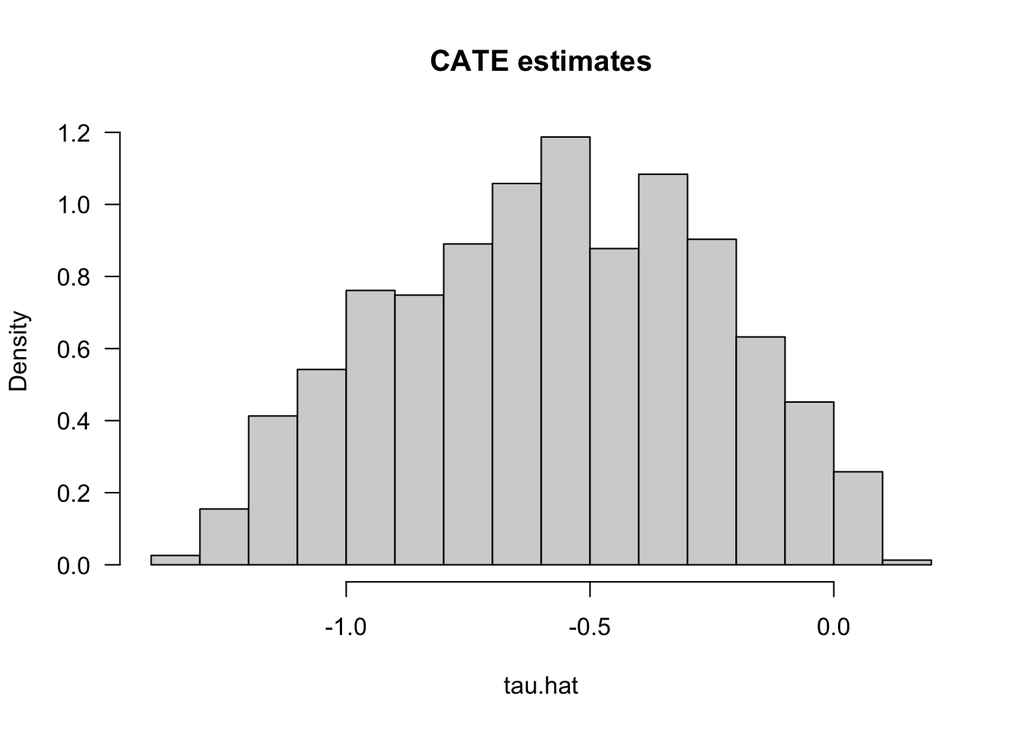

```r
forest.tau <- forest

# Get predicted differences from forest fitted above.
tau.hat <- predict(forest.tau)$predictions  # tau(X) estimates

hist(tau.hat, main="CATE estimates", freq=F, las=1)
```

```r
var_imp <- c(variable_importance(forest.tau))

names(var_imp) <- covariates
sorted_var_imp <- sort(var_imp, decreasing = TRUE)
sorted_var_imp#[1:10]  # showing only first five
```

```
##   mBZP1_sg    mCNP_sg    mEP1_sg        bmi    dehp_sg        age     mBP_sg
## 0.13473563 0.10469831 0.09598906 0.09234908 0.08652632 0.07938392 0.07740446
##    M_PB_sg    BP_3_sg    miBP_sg       year      educ1      white
## 0.07628723 0.07197787 0.07161413 0.04720677 0.01792478 0.00000000
```

In principle, the mean of the `tau.hat` predictions should equal the ATE. Let’s check:

```r
mean(tau.hat)
```

```
## [1] -0.5743027
```

It’s in the ballpark, but not quite the same. Let’s find out why…

```r
# Valid randomized data and observational data with unconfoundedness+overlap.
n <- nrow(new_afc)

# Number of rankings that the predictions will be ranking on
# (e.g., 2 for above/below median estimated CATE, 5 for estimated CATE quintiles, etc.)
num.rankings <- 3

# Prepare for data.splitting
# Assign a fold number to each observation.
# The argument 'clusters' in the next step will mimick K-fold cross-fitting.
num.folds <- 10
folds <- sort(seq(n) %% num.folds) + 1

# Comment or uncomment depending on your setting.
# Observational setting with unconfoundedness+overlap (unknown assignment probs):
forest <- causal_forest(X = covariates_matrix,
                        Y = outcome,
                        W = exposure,
                        num.trees = 2000,
                        honesty = TRUE,
                        min.node.size = 10,
                        alpha = .05,
                        imbalance.penalty = 0,
                        stabilize.splits = TRUE,
                        tune.parameters = "all",
                        tune.num.trees = 200,
                        tune.num.reps = 50,
                        tune.num.draws = 1000,
                        compute.oob.predictions = TRUE,
                        num.threads = 10,
                        seed = 123,
                        clusters = folds)

# Retrieve out-of-bag predictions.
# Predictions for observation in fold k will be computed using
# trees that were not trained using observations for that fold.
tau.hat <- predict(forest)$predictions

# Rank observations *within each fold* into quintiles according to their CATE predictions.
ranking <- rep(NA, n)
for (fold in seq(num.folds)) {
  tau.hat.quantiles <- quantile(tau.hat[folds == fold], probs = seq(0, 1, by=1/num.rankings))
  ranking[folds == fold] <- cut(tau.hat[folds == fold], tau.hat.quantiles, include.lowest=TRUE,labels=seq(num.rankings))
}

new_afc$ranking <- ranking
```

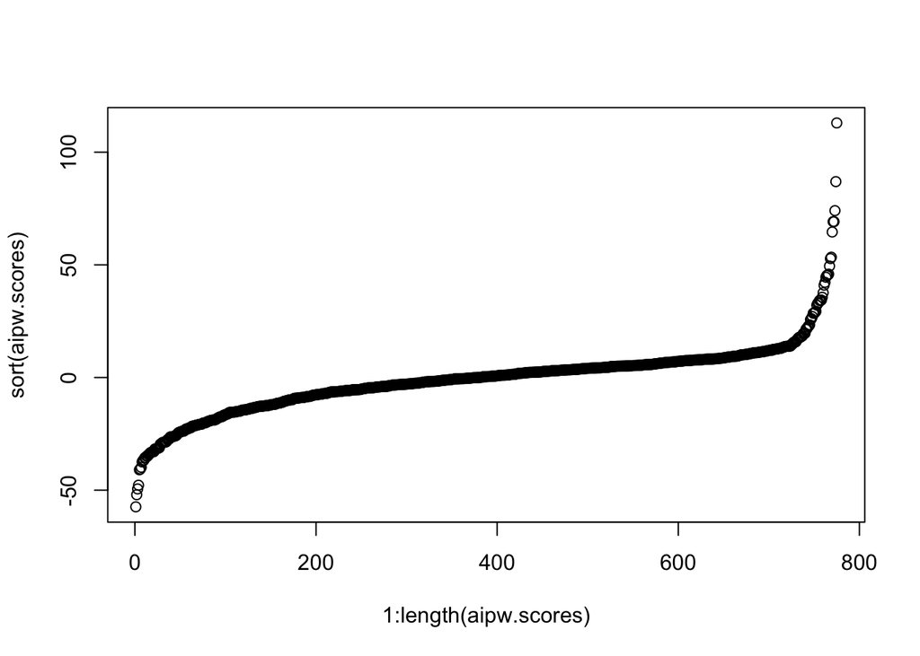

```r
# Computing AIPW scores.
e.hat <- forest$W.hat # P[W=1|X]
m.hat <- forest$Y.hat # E[Y|X]

Y <- outcome
W <- exposure

mu.hat.0 <- m.hat - e.hat*tau.hat # E[Y|X,W=0] = E[Y|X] - e(X)*tau(X)
mu.hat.1 <- m.hat + (1 - e.hat)*tau.hat  # E[Y|X,W=1] = E[Y|X] + (1 - e(X))*tau(X)

# AIPW scores
aipw.scores <- tau.hat + W / e.hat * (Y -  mu.hat.1) - (1 - W) / (1 - e.hat) * (Y -  mu.hat.0)

#Tryin something:

plot(
  1:length(aipw.scores),
  sort(aipw.scores)
  )
```

```r
ols <- lm(aipw.scores ~ 0 + factor(ranking))
forest.ate <- data.frame("aipw",
                         paste0("Q", seq(num.rankings)),
                         coeftest(ols, vcov = vcovHC(ols, "HC2"))[,1:2],
                         coefci(ols, vcov. = vcovHC(ols, "HC2"))[,1:2])
colnames(forest.ate) <- c("method", "ranking", "estimate", "std.err", "LCL", "UCL")
rownames(forest.ate) <- NULL # just for display
forest.ate
```

```
##   method ranking  estimate   std.err        LCL        UCL
## 1   aipw      Q1 -2.518708 1.0160384 -4.5132342 -0.5241828
## 2   aipw      Q2 -1.099068 0.9479224 -2.9598791  0.7617431
## 3   aipw      Q3  1.099162 0.9552910 -0.7761144  2.9744376
```

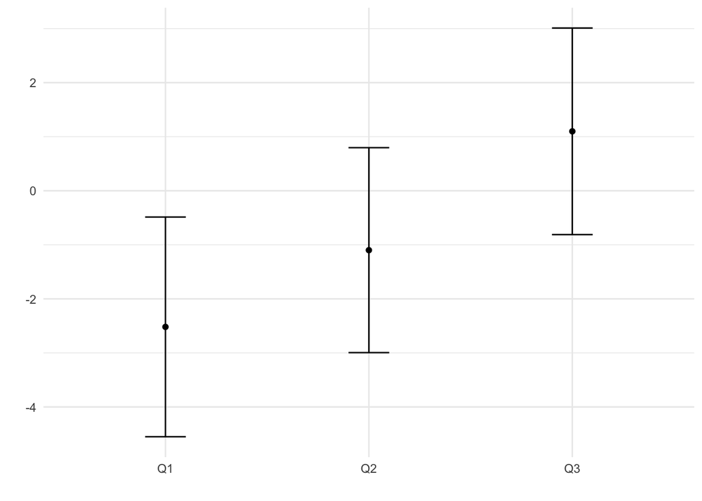

```r
# Plotting the point estimate of average treatment effect
# and 95% confidence intervals around it.
ggplot(forest.ate) +
  aes(x = ranking, y = estimate) +
  geom_point(position=position_dodge(0.2)) +
  geom_errorbar(aes(ymin=estimate-2*std.err, ymax=estimate+2*std.err), width=.2, position=position_dodge(0.2)) +
  ylab("") + xlab("") +
  theme_minimal() +
  theme(legend.position="bottom", legend.title = element_blank())
```

Formal test comparing quantile effects. First, we need code to run the Romano-Wolf correction for false discovery:

```r
# Auxiliary function to computes adjusted p-values
# following the Romano-Wolf method.
# For a reference, see http://ftp.iza.org/dp12845.pdf page 8
#  t.orig: vector of t-statistics from original model
#  t.boot: matrix of t-statistics from bootstrapped models
romano_wolf_correction <- function(t.orig, t.boot) {
  abs.t.orig <- abs(t.orig)
  abs.t.boot <- abs(t.boot)
  abs.t.sorted <- sort(abs.t.orig, decreasing = TRUE)

  max.order <- order(abs.t.orig, decreasing = TRUE)
  rev.order <- order(max.order)

  M <- nrow(t.boot)
  S <- ncol(t.boot)

  p.adj <- rep(0, S)
  p.adj[1] <- mean(apply(abs.t.boot, 1, max) > abs.t.sorted[1])
  for (s in seq(2, S)) {
    cur.index <- max.order[s:S]
    p.init <- mean(apply(abs.t.boot[, cur.index, drop=FALSE], 1, max) > abs.t.sorted[s])
    p.adj[s] <- max(p.init, p.adj[s-1])
  }
  p.adj[rev.order]
}

# Computes adjusted p-values for linear regression (lm) models.
#    model: object of lm class (i.e., a linear reg model)
#    indices: vector of integers for the coefficients that will be tested
#    cov.type: type of standard error (to be passed to sandwich::vcovHC)
#    num.boot: number of null bootstrap samples. Increase to stabilize across runs.
# Note: results are probabilitistic and may change slightly at every run.
#
# Adapted from the p_adjust from from the hdm package, written by Philipp Bach.
# https://github.com/PhilippBach/hdm_prev/blob/master/R/p_adjust.R
summary_rw_lm <- function(model, indices=NULL, cov.type="HC2", num.boot=10000) {

  if (is.null(indices)) {
    indices <- 1:nrow(coef(summary(model)))
  }
  # Grab the original t values.
  summary <- coef(summary(model))[indices,,drop=FALSE]
  t.orig <- summary[, "t value"]

  # Null resampling.
  # This is a trick to speed up bootstrapping linear models.
  # Here, we don't really need to re-fit linear regressions, which would be a bit slow.
  # We know that betahat ~ N(beta, Sigma), and we have an estimate Sigmahat.
  # So we can approximate "null t-values" by
  #  - Draw beta.boot ~ N(0, Sigma-hat) --- note the 0 here, this is what makes it a *null* t-value.
  #  - Compute t.boot = beta.boot / sqrt(diag(Sigma.hat))
  Sigma.hat <- vcovHC(model, type=cov.type)[indices, indices]
  se.orig <- sqrt(diag(Sigma.hat))
  num.coef <- length(se.orig)
  beta.boot <- mvrnorm(n=num.boot, mu=rep(0, num.coef), Sigma=Sigma.hat)
  t.boot <- sweep(beta.boot, 2, se.orig, "/")
  p.adj <- romano_wolf_correction(t.orig, t.boot)

  result <- cbind(summary[,c(1,2,4),drop=F], p.adj)
  colnames(result) <- c('Estimate', 'Std. Error', 'Orig. p-value', 'Adj. p-value')
  result
}
```

Now we make the comparisons:

```r
# Valid in randomized and observational settings with unconfoundedness+overlap.

# Using AIPW scores computed above
ols <- lm(aipw.scores ~ 1 + factor(ranking))
summary(ols)
```

```
##
## Call:
## lm(formula = aipw.scores ~ 1 + factor(ranking))
##
## Residuals:
##     Min      1Q  Median      3Q     Max
## -54.863  -6.976   0.983   7.125 115.489
##
## Coefficients:
##                  Estimate Std. Error t value Pr(>|t|)
## (Intercept)       -2.5187     0.9708  -2.594  0.00965 **
## factor(ranking)2   1.4196     1.3796   1.029  0.30380
## factor(ranking)3   3.6179     1.3729   2.635  0.00858 **
## ---
## Signif. codes:  0 '***' 0.001 '**' 0.01 '*' 0.05 '.' 0.1 ' ' 1
##
## Residual standard error: 15.65 on 772 degrees of freedom
## Multiple R-squared:  0.009049,   Adjusted R-squared:  0.006482
## F-statistic: 3.525 on 2 and 772 DF,  p-value: 0.02993
```

```r
res <- summary_rw_lm(ols, indices=2:num.rankings)
rownames(res) <- paste("Rank", 2:num.rankings, "- Rank 1") # just for display
res
```

```
##                 Estimate Std. Error Orig. p-value Adj. p-value
## Rank 2 - Rank 1  1.41964   1.379636    0.30380358       0.3109
## Rank 3 - Rank 1  3.61787   1.372922    0.00857844       0.0141
```

Let’s do a little more digging. Let’s look at how the covariates in our models differ across levels of these tertiles:

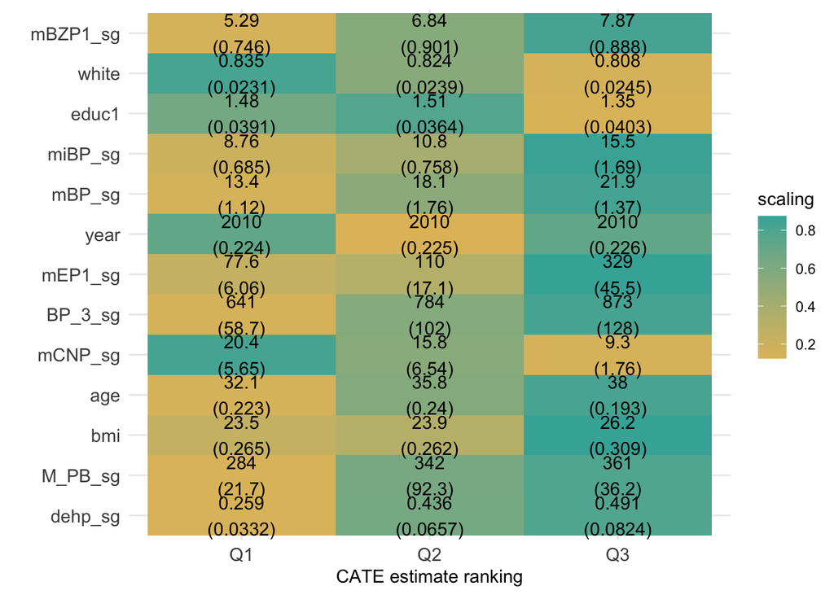

```r
## ----avg-cov-cate, fig.align = 'center', fig.cap= "Average covariate values within group (based on CATE estimate ranking)"----

avg_cov_cate <- function(covariate, data=new_afc) {
      # Looping over covariate names
      # Compute average covariate value per ranking (with correct standard errors)
      fmla <- formula(paste0(covariate, "~ 0 + ranking"))
      ols <- lm(fmla, data=transform(data, ranking=factor(ranking)))
      ols.res <- coeftest(ols, vcov=vcovHC(ols, "HC2"))

      # Retrieve results
      avg <- ols.res[,1]
      stderr <- ols.res[,2]

      # Tally up results
      data.frame(covariate, avg, stderr, ranking=paste0("Q", seq(num.rankings)),
                 # Used for coloring
                 scaling=pnorm((avg - mean(avg))/sd(avg)),
                 # We will order based on how much variation is 'explain' by the averages
                 # relative to the total variation of the covariate in the data
                 variation=sd(avg) / sd(as.matrix(data[,covariate])),
                 # String to print in each cell in heatmap below
                 labels=paste0(signif(avg, 3), "\n", "(", signif(stderr, 3), ")")
                 )
}

df <- mapply(avg_cov_cate, covariates, SIMPLIFY = FALSE)
df <- do.call(rbind, df)

# a small optional trick to ensure heatmap will be in decreasing order of 'variation'
df$covariate <- reorder(df$covariate, order(df$variation))

# plot heatmap
ggplot(df) +
    aes(ranking, covariate) +
    geom_tile(aes(fill = scaling)) +
    geom_text(aes(label = labels)) +
    scale_fill_gradient(low = "#E1BE6A", high = "#40B0A6") +
    theme_minimal() +
    ylab("") + xlab("CATE estimate ranking") +
    theme(plot.title = element_text(size = 11, face = "bold"),
          axis.text=element_text(size=11))
```

Let’s also look at the best linear projection of the mean differences on the covariates. This gives us another sense of which variables explain the heterogeneity in the ATE:

```r
# Best linear projection of the conditional average treatment effect on covariates
best_linear_projection(forest.tau, covariates_matrix)
```

```
##
## Best linear projection of the conditional average treatment effect.
## Confidence intervals are cluster- and heteroskedasticity-robust (HC3):
##
##                Estimate  Std. Error t value  Pr(>|t|)
## (Intercept) -1.0046e+02  3.0136e+02 -0.3334 0.7389430
## age          2.3501e-01  1.3048e-01  1.8011 0.0720809 .
## bmi          2.9335e-02  1.5766e-01  0.1861 0.8524452
## white       -2.0736e+00  1.3687e+00 -1.5151 0.1301714
## year         4.6252e-02  1.4957e-01  0.3092 0.7572339
## educ1       -9.9156e-01  9.7973e-01 -1.0121 0.3118243
## mEP1_sg      4.7206e-03  1.3753e-03  3.4324 0.0006306 ***
## mBZP1_sg     3.8629e-02  3.3207e-02  1.1633 0.2450756
## mCNP_sg      2.9881e-04  4.2820e-03  0.0698 0.9443847
## miBP_sg      1.9473e-02  1.8911e-02  1.0297 0.3034757
## mBP_sg      -2.7757e-02  2.3590e-02 -1.1766 0.2397048
## BP_3_sg      2.0537e-04  2.7537e-04  0.7458 0.4560045
## M_PB_sg     -2.3071e-04  1.3300e-03 -0.1735 0.8623283
## dehp_sg      2.2156e-01  3.5631e-01  0.6218 0.5342559
## ---
## Signif. codes:  0 '***' 0.001 '**' 0.01 '*' 0.05 '.' 0.1 ' ' 1
```

But why linear? How does this differ from the variable importance measures we quantified above?

“The slope beta is a measure of how the CATE predictions covary with true CATE. Therefore, the p-value on the estimate of coefficient also acts as an omnibus test for the presence of heterogeneity. If the coefficient is significantly greater than zero, then we can reject the null of no heterogeneity. However, coefficients smaller than 0 are not meaningful and show not be interpreted.”

```r
test_calibration(forest.tau)
```

```
##
## Best linear fit using forest predictions (on held-out data)
## as well as the mean forest prediction as regressors, along
## with one-sided heteroskedasticity-robust (HC3) SEs:
##
##                                Estimate Std. Error t value Pr(>t)
## mean.forest.prediction          1.10174    0.99607  1.1061 0.1345
## differential.forest.prediction  0.14175    1.75347  0.0808 0.4678
```

Hannah’s stuff:

```r
# Training a Causal Forest for CATE: smoking


# Sample Splitting:

split <- sample(c(FALSE, TRUE), nrow(afc), replace = TRUE)
afc.train <- afc[split,]
afc.hold <- afc[!split,]

# Isolate the "treatment" as a matrix
x<-as.matrix(afc.train$eversmok)

# Isolate the outcome as a matrix
y<-as.matrix(afc.train$AFC_t)

# Adding interaction terms
w<- model.matrix(lm(AFC_t ~ -1 + bmi + white + age + year + DOR + educ1 + mBP_sg +
  miBP_sg + mCNP_sg + mCOP_sg + mECPP_sg + mEHHP_sg + mEHP_sg + mEOHP_sg +  mCPP_sg + mEP1_sg + mBZP1_sg + dehp_sg + BPA_sg + BPS_sg + BPF_sg + BP_3_sg + B_PB_sg + M_PB_sg + P_PB_sg + TCS_sg + BDCIPP_sg + DPHP_sg + ipPPP_sg + Hg_new, data=afc.train))


#Estimate causal forest

cf_smoke <- causal_forest(x, y, w, num.trees = 5000)












#train causal forest
#forest_smoke <- causal_forest(x_smoke, y, w_smoke)
#forest_smoke$predictions

# get ATE
#average_treatment_effect(forest_smoke, target.sample ="all")
#?average_treatment_effect

##   estimate    std.err
## -0.2463795  0.7234440
```